# Chapter 17 — Practice Challenge Solutions

←Back to the bookChapter 17 · Take the quiz & aim for 100%

Chapter 17 · Solutions

Practice Challenges, Worked Answers ✅

Full solutions to the five "Choosing the Right Visualization" challenges. Try them yourself first, then compare.

Statistics, Data Science and AI: A Visual Handbook · John Fisher · 2026

## ⚙️ Setup

```python
import numpy as np
import pandas as pd
import matplotlib.pyplot as plt

rng = np.random.default_rng(177)
INK="#1a2138"; INK_SOFT="#4a5578"; CYAN="#0891b2"; PURPLE="#7c3aed"; AMBER="#d97706"; GREEN="#059669"; PINK="#db2777"; GRID="#e6e9f2"; GRAY="#c7ccda"
plt.rcParams.update({"figure.facecolor":"white","axes.facecolor":"white","figure.dpi":110,"font.size":11,
   "axes.edgecolor":GRID,"axes.grid":True,"grid.color":GRID,"axes.axisbelow":True,"axes.spines.top":False,
   "axes.spines.right":False,"axes.titlesize":12,"axes.titleweight":"bold","legend.frameon":False})
print("Ready.")
```

```
Ready.
```

CHALLENGE 1 · NAME THE CHART

Match purpose to chart

For each question, name the purpose and the best chart: (a) which of 6 stores had the highest sales? (b) how did website traffic change over 24 months? (c) how are customer ages distributed? (d) do study hours and exam scores relate?

```python
rows = [
  ("(a) highest of 6 stores", "Comparison/Ranking", "sorted bar chart"),
  ("(b) traffic over 24 months", "Trend over time", "line chart"),
  ("(c) distribution of ages", "Distribution", "histogram (or box plot)"),
  ("(d) study hours vs scores", "Relationship", "scatter plot"),
]
for q,p,c in rows: print(f"{q:30} | {p:18} -> {c}")
```

```
(a) highest of 6 stores        | Comparison/Ranking -> sorted bar chart
(b) traffic over 24 months     | Trend over time    -> line chart
(c) distribution of ages       | Distribution       -> histogram (or box plot)
(d) study hours vs scores      | Relationship       -> scatter plot
```

**Answer:** (a) **comparison/ranking → sorted bar**; (b) **trend over time → line**; (c) **distribution → histogram** (box plot if comparing groups); (d) **relationship → scatter**. Name the purpose first and the chart follows.

CHALLENGE 2 · BAR, NOT PIE

Comparison done right

Six teams have these resolved-ticket counts. Draw the chart that lets a reader rank them at a glance, and explain in one line why a pie would be worse.

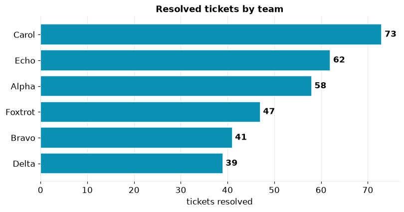

```python
tickets = pd.Series({"Alpha":58,"Bravo":41,"Carol":73,"Delta":39,"Echo":62,"Foxtrot":47}).sort_values()
fig, ax = plt.subplots(figsize=(7.5,4))
ax.barh(tickets.index, tickets.values, color=CYAN, edgecolor="white"); ax.grid(axis="y", visible=False)
ax.set_xlabel("tickets resolved"); ax.set_title("Resolved tickets by team")
for i,v in enumerate(tickets.values): ax.text(v+0.6, i, str(v), va="center", fontweight="bold")
plt.tight_layout(); plt.show()
```

**Answer:** A **sorted horizontal bar chart**: every value sits on a common scale, so the ranking and the near-ties read instantly. A pie would force the eye to compare six similar **angles**, which we judge far worse than bar **lengths**, and six slices is already past the comfortable pie limit.

CHALLENGE 3 · MAKE IT EXPLANATORY

From default to a clear message

These monthly defect rates have one bad month. Redraw a plain bar chart as an explanatory one: highlight the problem month, gray the rest, and give it a takeaway title.

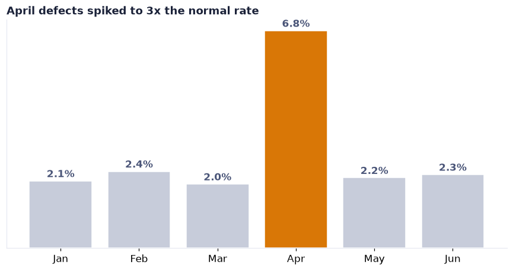

```python
months = ["Jan","Feb","Mar","Apr","May","Jun"]
defects = np.array([2.1, 2.4, 2.0, 6.8, 2.2, 2.3])
worst = int(np.argmax(defects))
colors = [AMBER if i==worst else GRAY for i in range(len(months))]
fig, ax = plt.subplots(figsize=(8,4.3))
ax.bar(months, defects, color=colors, edgecolor="white")
ax.set_title("April defects spiked to 3x the normal rate", loc="left", color=INK)
ax.grid(False); ax.set_yticks([])
for i,v in enumerate(defects): ax.text(i, v+0.12, f"{v}%", ha="center", fontweight="bold", color=INK_SOFT)
plt.tight_layout(); plt.show()
```

**Answer:** Keep the bar chart (comparison across months) but make it argue: **gray every normal month**, color **April** in amber, drop the gridlines and y-axis clutter, label the bars directly, and replace an axis-only title with the **takeaway** ("April defects spiked..."). The reader now sees the conclusion, not just the data.

CHALLENGE 4 · EXPLORATORY OR EXPLANATORY

Know your audience

You are (a) scanning a new dataset for yourself, and (b) presenting one finding to executives. How should the charts differ, and what makes a good explanatory title?

```python
print("(a) EXPLORATORY (for you): many quick, rough charts; defaults are fine; goal = find what matters.")
print("(b) EXPLANATORY (for execs): a few polished charts; ONE takeaway each; declutter + highlight + annotate.")
print("\nGood explanatory title states the CONCLUSION, e.g.")
print("   weak : 'Revenue by quarter'")
print("   strong: 'Revenue grew 18% after the April relaunch'")
```

```
(a) EXPLORATORY (for you): many quick, rough charts; defaults are fine; goal = find what matters.
(b) EXPLANATORY (for execs): a few polished charts; ONE takeaway each; declutter + highlight + annotate.

Good explanatory title states the CONCLUSION, e.g.
   weak : 'Revenue by quarter'
   strong: 'Revenue grew 18% after the April relaunch'
```

**Answer:** **Exploratory** work is for you: make many fast, rough charts and see everything. **Explanatory** work is for an audience: a few polished charts, each with **one clear takeaway**, decluttered, with the key element highlighted. A good explanatory title states the **conclusion** ("Revenue grew 18% after the April relaunch"), not just the axes ("Revenue by quarter").

CHALLENGE 5 · MAYBE NO CHART

Number, table, or chart?

Pick number, table, or chart for each: (a) a single KPI, customer satisfaction = 4.6 / 5; (b) exact monthly revenue for 4 quarters that finance will read off; (c) the shape of 10,000 transaction amounts.

```python
choices = {
  "(a) single KPI 4.6/5":            "NUMBER  (one value -> just show it big)",
  "(b) 4 exact revenue figures":     "TABLE   (precise look-up values)",
  "(c) shape of 10,000 amounts":     "CHART   (a histogram -> distribution)",
}
for q,a in choices.items(): print(f"{q:34} -> {a}")
```

```
(a) single KPI 4.6/5               -> NUMBER  (one value -> just show it big)
(b) 4 exact revenue figures        -> TABLE   (precise look-up values)
(c) shape of 10,000 amounts        -> CHART   (a histogram -> distribution)
```

**Answer:** (a) **a number**, one KPI is clearest shown big; (b) **a table**, when readers must look up exact values a table beats a chart; (c) **a chart** (histogram), because the *shape* of 10,000 values is exactly what a chart reveals and a table never could. Always gate a chart with "would a number or table say this more clearly?"

🎉 Nicely done!

You matched purposes to charts, chose a bar over a pie, turned a default into an explanatory chart, separated exploratory from explanatory work, and decided when a number or table beats a chart. You now choose visuals on purpose, which is what closes out the visualization toolkit.

Statistics, Data Science and AI: A Visual Handbook · © 2026 John Fisher

←Back to the bookChapter 17 · Take the quiz & aim for 100%